# An Anlysis of CO2 Emission

Ye Li

1/17/2020

## Introduction

This is a mini-report to analyze and visualize the **EDGAR CO2 emissions 1970-2018** dataset. The dataset is downloaded from the GitHub repository at https://github.com/openclimatedata/edgar-co2-emissions on January 23, 2020.

The dataset was originally reported in Crippa, M., Oreggioni, G., Guizzardi, D., Muntean, M., Schaaf, E., Lo Vullo, E., Solazzo, E., Monforti-Ferrario, F., Olivier, J.G.J., Vignati, E., Fossil CO2 and GHG emissions of all world countries - 2019 Report, EUR 29849 EN, Publications Office of the European Union, Luxembourg, 2019, ISBN 978-92-76-11100-9, [https://doi.org/10.2760/687800, JRC117610.](https://doi.org/10.2760/687800,%20JRC117610.)

More about the dataset and similar climate datasets can be found at https://openclimatedata.net/

## Data

Here are the first few rows of the dataset.

```
##   Code                Name         Sector Year    Emissions
## 1  AFG         Afghanistan Power Industry 1970 0.0569621300
## 2  ALB             Albania Power Industry 1970 0.6006240000
## 3  DZA             Algeria Power Industry 1970 1.6458690000
## 4  AGO              Angola Power Industry 1970 0.1375463000
## 5  AIA            Anguilla Power Industry 1970 0.0004299514
## 6  ATG Antigua and Barbuda Power Industry 1970 0.0538223200
```

It contains columns **Code, Name, Sector, Year, Emissions**. They are the country code, country Name, cateogrical sectors, year of CO2 emission was calculated, and the emission in Megaton (Mt) CO₂ per year. The categorical sectors include Buildings, Other industrial combustion, Other sectors, Power Industry, Transport.

The unit megaton (Mt) for the Emission column was not noted in the original dataset. We found the unit in the README.md file of the original GitHub repo at https://github.com/openclimatedata/edgar-co2-emissions and added the unit to the column name as **Emissions_Mt** and saved the new dataset under the *data_derived* subfolder.

## Carbon Dioxide emissions from different sectors in the U.S.

We can filter out data for the United States and plot them in the following figure.

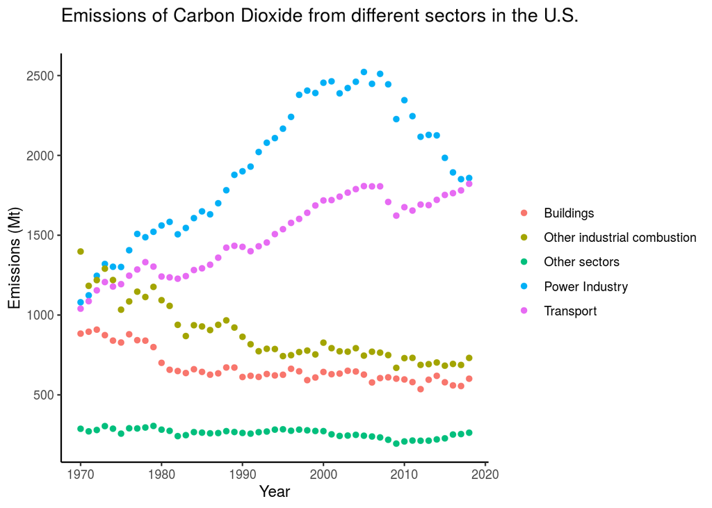

[figure not shown]

[figure not shown]

[figure not shown]